# pca

2024-01-16

So we got an image:

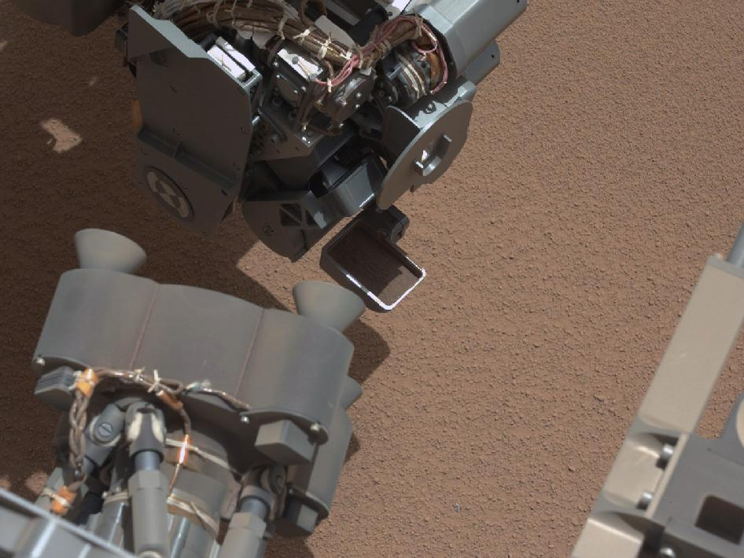

There’s a strange object in the sand .. and we want to better highlight that using some stats approach.

Let’s import into R!

```r
library(jpeg)
img <- readJPEG('image.jpg')
```

Looking at the structure:

```r
str(img)
```

```
##  num [1:710, 1:946, 1:3] 0.345 0.322 0.29 0.271 0.271 ...
```

This seems to be a 3D array!

Checking on the first pixel:

```r
img[1, 1, ]
```

```
## [1] 0.3450980 0.2784314 0.2470588
```

```r
col <- do.call(rgb, as.list(img[1, 1, ]))
col
```

```
## [1] "#58473F"
```

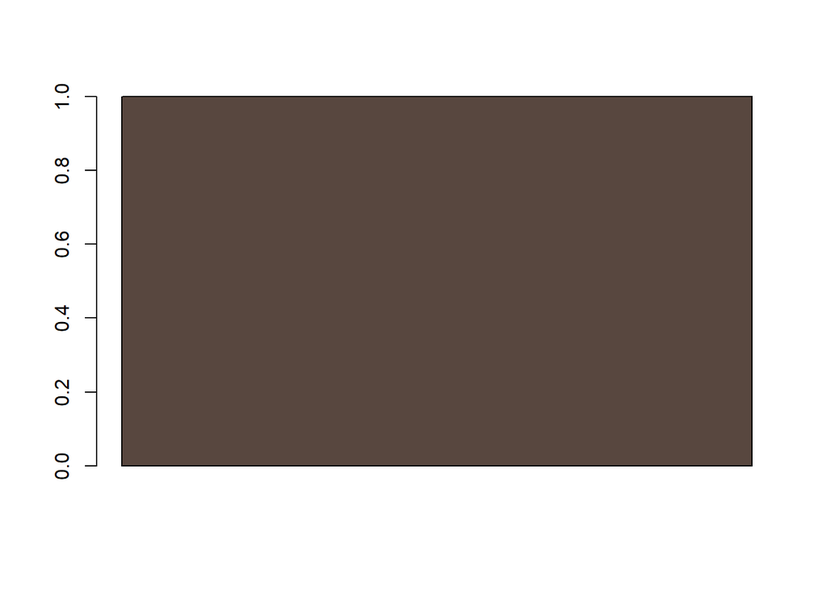

```r
barplot(1, col = col)
```

Let’s record image height and width as we will need later:

```r
dim(img)
```

```
## [1] 710 946   3
```

```r
h <- dim(img)[1]
w <- dim(img)[2]
```

Now we can transform the 3D array into a 2D table with `h`*`w` rows and 3 columns for the RGB values:

```r
img1d <- matrix(img, h * w)
str(img1d)
```

```
##  num [1:671660, 1:3] 0.345 0.322 0.29 0.271 0.271 ...
```

And we are ready to run principal component analysis!

```r
pca <- prcomp(img1d)
pca
```

```
## Standard deviations (1, .., p=3):
## [1] 0.275549108 0.051454792 0.006787604
##
## Rotation (n x k) = (3 x 3):
##            PC1        PC2        PC3
## [1,] 0.6228067  0.7149012 -0.3178492
## [2,] 0.5753627 -0.1432200  0.8052613
## [3,] 0.5301599 -0.6844007 -0.5005258
```

```r
summary(pca)
```

```
## Importance of components:
##                           PC1     PC2      PC3
## Standard deviation     0.2755 0.05145 0.006788
## Proportion of Variance 0.9657 0.03368 0.000590
## Cumulative Proportion  0.9657 0.99941 1.000000
```

Recap on PCA: the rotation matrix is the the eigenvectors of the covariance matrix.

```r
pca$rotation
```

```
##            PC1        PC2        PC3
## [1,] 0.6228067  0.7149012 -0.3178492
## [2,] 0.5753627 -0.1432200  0.8052613
## [3,] 0.5301599 -0.6844007 -0.5005258
```

```r
eigen(cov(img1d))$vectors
```

```
##            [,1]       [,2]       [,3]
## [1,] -0.6228067  0.7149012  0.3178492
## [2,] -0.5753627 -0.1432200 -0.8052613
## [3,] -0.5301599 -0.6844007  0.5005258
```

Recap on PCA: how to get the actual scores?

```r
str(pca$x)
```

```
##  num [1:671660, 1:3] -0.145 -0.185 -0.24 -0.273 -0.273 ...
##  - attr(*, "dimnames")=List of 2
##   ..$ : NULL
##   ..$ : chr [1:3] "PC1" "PC2" "PC3"
```

```r
## multiply the standardized numbers by the weights
str(sweep(img1d, 2, colMeans(img1d)) %*% pca$rotation)
```

```
##  num [1:671660, 1:3] -0.145 -0.185 -0.24 -0.273 -0.273 ...
##  - attr(*, "dimnames")=List of 2
##   ..$ : NULL
##   ..$ : chr [1:3] "PC1" "PC2" "PC3"
```

```r
str(scale(img1d, scale = FALSE) %*% pca$rotation)
```

```
##  num [1:671660, 1:3] -0.145 -0.185 -0.24 -0.273 -0.273 ...
##  - attr(*, "dimnames")=List of 2
##   ..$ : NULL
##   ..$ : chr [1:3] "PC1" "PC2" "PC3"
```

What are these components really?

```r
cor(pca$x[, 1], img1d)
```

```
##           [,1]      [,2]     [,3]
## [1,] 0.9777161 0.9983296 0.971904
```

```r
cor(pca$x, img1d)
```

```
##            [,1]        [,2]        [,3]
## PC1  0.97771606  0.99832960  0.97190396
## PC2  0.20957152 -0.04640477 -0.23429000
## PC3 -0.01229131  0.03441807 -0.02260271
```

```r
extractColors <- function(x) rgb(x[1], x[2], x[3])
(colors <- apply(abs(pca$rotation), 2, extractColors))
```

```
##       PC1       PC2       PC3
## "#9F9387" "#B625AF" "#51CD80"
```

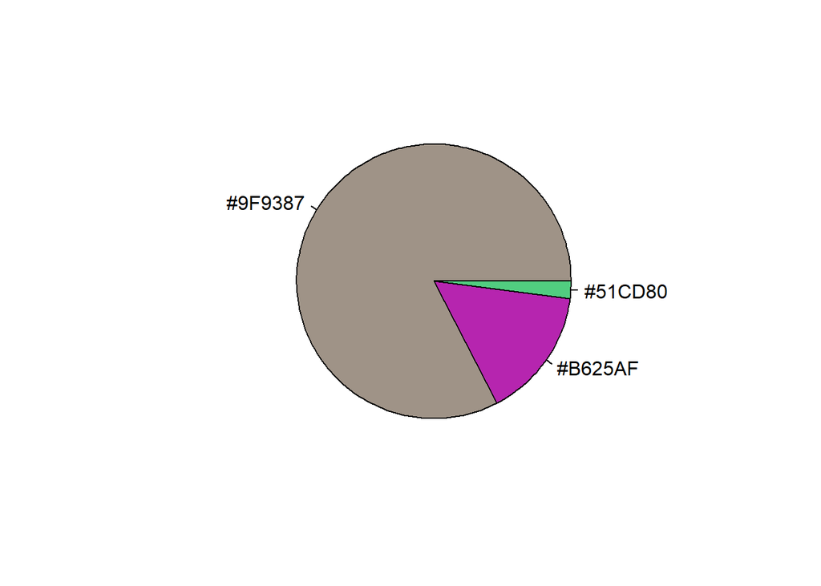

```r
pie(pca$sdev, col = colors, labels = colors)
```

Okay, enough playing with this .. what did we achieve? Let’s redraw the original image with artificial colors based on the components:

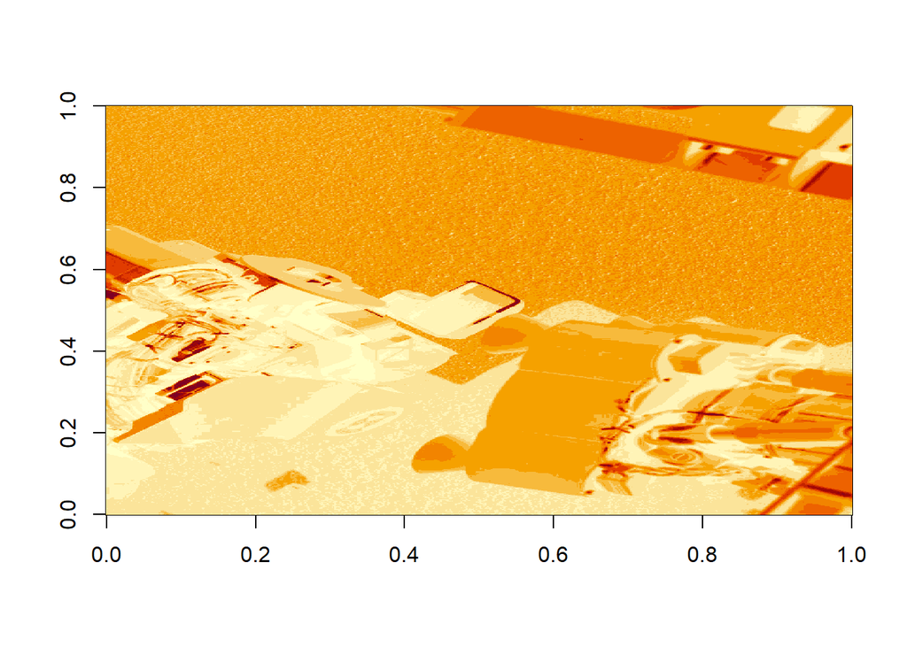

```r
image(matrix(pca$x[, 1], h))
```

Maybe another component?

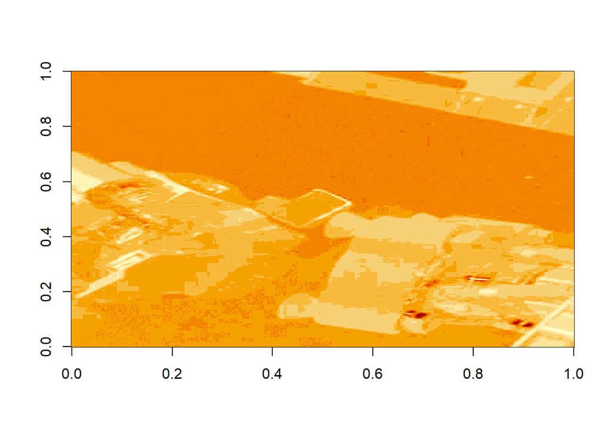

```r
image(matrix(pca$x[, 2], h))
```

Reduce to monochrome:

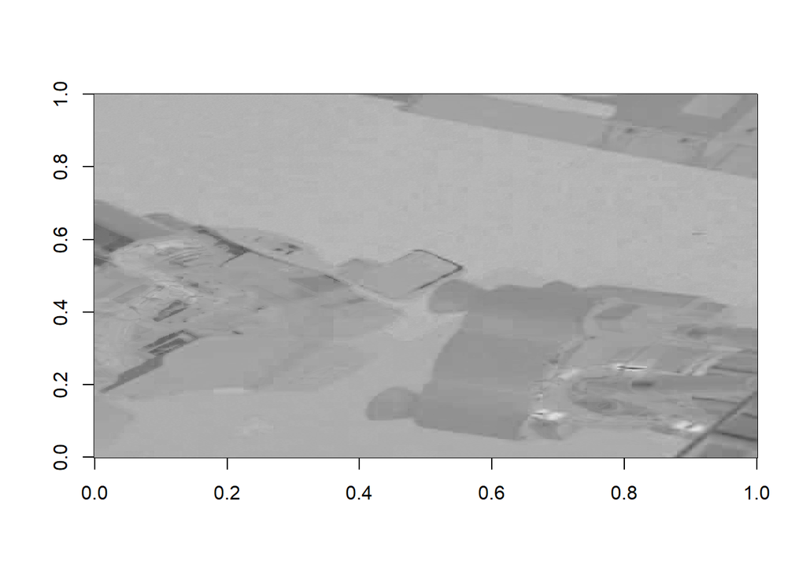

```r
image(matrix(pca$x[, 2], h), col = gray.colors(100))
```

You can read a much more detailed post on this at http://bit.ly/r-intro-pca-blog, and find more on PCA at https://stats.stackexchange.com/a/140579.